# Confidence Intervals: Bayesian vs. Frequentist

```r
library(tidyverse)
```

# Random Variables

# Quantifying Confidence in a Sample Proportion

Does drug A or drug B work better?

Suppose that if we extract a random sick person from the general population and give them drug A, then the probability that that person would recover from their sickness is $\theta_A$. $\theta_A$ is the true proportion of sick people treated with drug A that recover.

If we were to extract a random sick person from the general population and give them drug B, then the probability that we’d see that person recover from their sickness is $\theta_B$. $\theta_B$ is the true proportion of sick people treated with drug B that recover.

Suppose that we don’t known the true value of $\theta_A$, nor the true value of $\theta_B$.

We do the following:

1. We give 100 random sick people drug A. We observe that 90 of them recover. This data gives us a point estimate $\hat\theta_A=0.9$ of $\theta_A$.
2. We give 100 random sick people drug B. 95 of them recover. This gives us a point estimate $\hat\theta_B=0.95$ of $\theta_B$.

How can we objectively quantify our uncertainty in these estimates $\hat\theta_A$ and $\hat\theta_B$, and in the difference between them?

# Confidence in a Sample Proportion: Bayesian Approach

The basic logic behind the Bayesian approach is this:

- $\theta_A$ is the true proportion of sick people on drug A who recover in the population. We don’t know the value of $\theta_A$. Therefore, we consider $\theta_A$ a random variable.
- If we take a random sample of 100 sick people and give them drug A, then $X$ of them will recover. $X$, then, is also a random variable. The distribution of $X$ is clearly highly dependent on the value of random variable $\theta_A$.
- Using results from conditional probability ([Bayes Theorem](https://www.youtube.com/watch?v=HZGCoVF3YvM)), we can calculate the [conditional distribution](https://en.wikipedia.org/wiki/Conditional_probability_distribution) of $\theta_A$ given that the outcome ($x$) of the random variable $X$ has been observed:

$$\overset{posterior}{\overbrace{f\Big(\theta_A \space\Bigl|X=x\Big)}}
\quad=\quad
\displaystyle\frac{\overset{likelihood}{\overbrace{Pr\Big[X=x\space\Bigl|\theta_A\Big]}}\cdot \overset{prior}{\overbrace{f(\theta_A)}}}{\underset{\theta_A}{\displaystyle\int} Pr\Big[X=x\space\Bigl|\theta_A\Big]\cdot f(\theta_A) \hspace{2mm} d\theta_A}$$

This means that if we are comfortable assuming a marginal distribution (*prior*) $f(\theta_A)$ for $\theta_A$ (distribution of $\theta_A$ ignoring $X$) and assuming the form of the conditional distribution $Pr\Big[X=x\Bigl|\theta_A\Big]$ of $X$, then we get “**the conditional distribution of $\theta_A$ given $X$**” (the distribution of parameter of interest $\theta_A$, having taken into account the evidence provided by our data $X$).

The conditional distribution of our data $X\Bigl|\theta_A$ (the *likelihood*) is easy: we assume that each randomly drawn sick individual from the population who is given drug A has a probability $\theta_A$ of recovering. This gives the following distribution for $X\Bigl|\theta_A$:

$$\begin{array}{lcl} X \space \Bigl| \space \theta_A &\sim& \text{Binomial}\Big(n=100, \quad prob=\theta_A\Big) \\
Pr\Big[X=x \space\Bigl|\space\theta_A \Big] &=& \displaystyle\binom{100}{x} \cdot (\theta_A)^{x} \cdot (1-\theta_A)^{100-x} \\
\end{array}$$

See https://en.wikipedia.org/wiki/Binomial_distribution for details.

The choice of the *prior* distribution $f(\theta_A)$ is more subjective, and a point of some contention. This distribution must quantify our belief in different possible values of $\theta_A$ before having observed our data $X$.

For our data, suppose that we choose the following **prior distribution** for $\theta_A$:

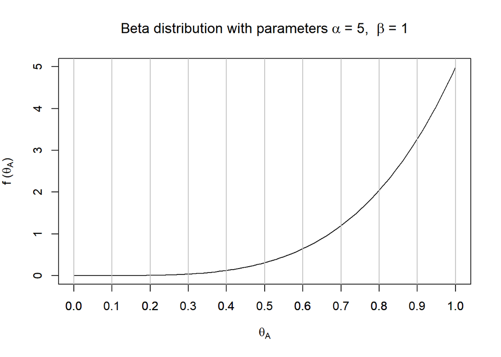

Notice that we are specifying that we believe that higher values of $\theta_A$ are much more likely than lower values. The choice of prior should in practice be justified by evidence.

The choice of a **beta** distribution for the **prior distribution** here is for mathematical convenience (see https://en.wikipedia.org/wiki/Conjugate_prior).

Combining this choice of prior $f(\theta_A)$ with our binomial likelihood $Pr\Big[X=x \space\Bigl|\space\theta_A \Big]$ gives us our **posterior distribution** of $\theta_A$:

$$\begin{array}{lcl} f\Big(\theta_A \space\Bigl|X=90\Big)
&=& \text{Beta}\Big(\alpha=5+90, \quad \beta=1+100-90\Big) \\
&=& \text{Beta}\Big(\alpha=95, \quad \beta=11\Big) \\
\end{array}$$

For details on this calculation, see https://stats.stackexchange.com/questions/70661/how-does-the-beta-prior-affect-the-posterior-under-a-binomial-likelihood.

Here is an illustration of these **prior** and **posterior** distributions:

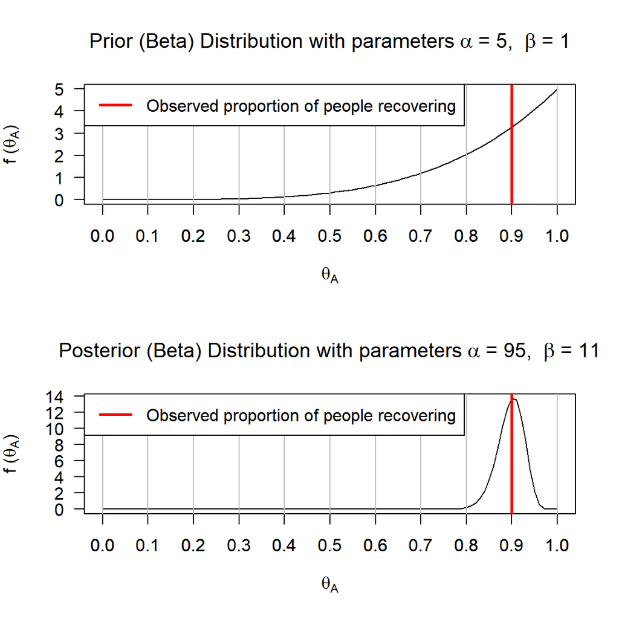

Here is another way to think about this:

1. Suppose that we draw out a million values of $\theta_A$ from the prior distribution $\text{beta}\Big(5,1\Big)$:

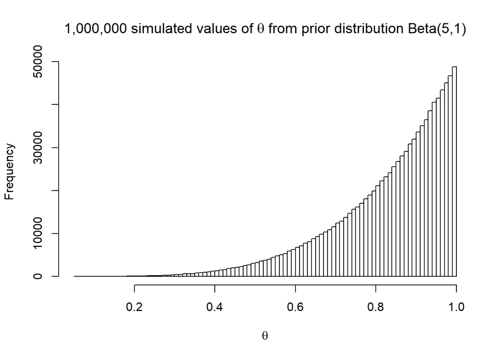

```r
theta_A_sample <- rbeta( n=1e6L, shape1=5, shape2=1 )
hist(      x = theta_A_sample,
      breaks = 70,
        main = bquote( "1,000,000 simulated values of"~theta~"from prior distribution Beta(5,1)"),
        xlab = bquote(theta)
    )
```

2. Now, suppose that for each value $\theta_A^{(i)}: \hspace{4mm} i=1,...,1\hspace{1mm}000\hspace{1mm}000$ of the million $\theta_A$ values, we simulate a binomial value $X_i \sim \text{Binomial}\Big(n=100, \space prob=\theta_A^{(i)}\Big)$:

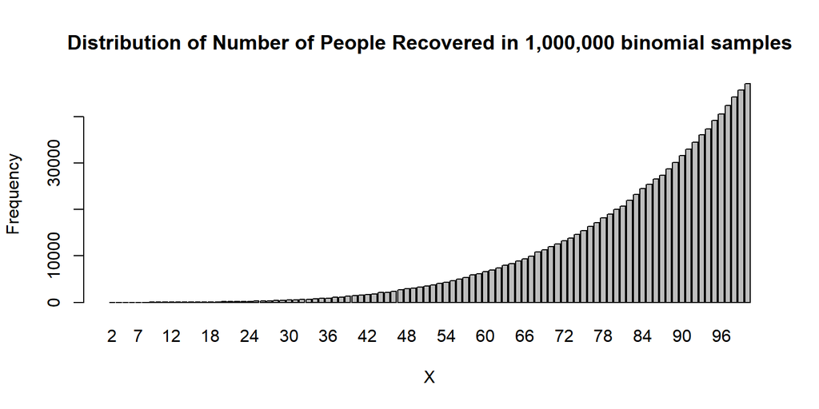

```r
binomial_data_sample <-
  rbinom(    n = length(theta_A_sample),
          size = 100,
          prob = theta_A_sample
        )

barplot(         table(binomial_data_sample),
          xlab = "X",
          ylab = "Frequency",
          main = "Distribution of Number of People Recovered in 1,000,000 binomial samples"
        )
```

3. Now, we can look at the distribution of the values $\theta_A^{(i)}$ ONLY ON THE SAMPLES $i$ IN WHICH WE SAW $X_i=90$: (this happened in 31611 out of the million binomial values)

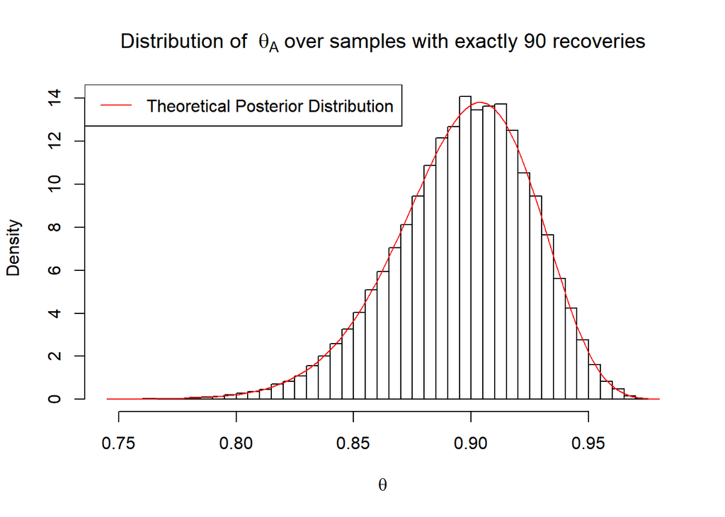

```r
posterior_theta_A_sample <- theta_A_sample[ binomial_data_sample == 90 ]

hist(      x = posterior_theta_A_sample,
      breaks = 50,
        freq = FALSE,
        xlab = bquote(theta),
        main = bquote( "Distribution of "~theta[A]~"over samples with exactly 90 recoveries" )
    )

curve( dbeta( x, shape1=95, shape2=11),
       add = TRUE,
       col = 2
      )

legend(          "topleft",
        legend = "Theoretical Posterior Distribution",
           lty = 1,
           col = 2
      )
```

# Confidence in a Sample Proportion: Frequentist Approach

The frequentist approach to this problem is to choose a method for creating confidence intervals which we know will contain the true value of $\theta_A$ in a certain proportion of datasets.

For example, if we draw a whole lot of random samples, each of 100 people, from the population of sick people, give them drug A, and calculate the following confidence interval for each of the samples:

$$\Bigg[\underset{\quad lower}{\underbrace{\displaystyle\frac{1}{1+\displaystyle\frac{n-x+1}{x}F_{2(n-x+1), 2x, \frac{\alpha}{2}}}}} \quad;\quad \underset{upper}{\underbrace{\displaystyle\frac{\displaystyle\frac{x+1}{n-x}F_{2(x+1),2(n-x),\frac{\alpha}{2}}}{1 + \displaystyle\frac{x+1}{n-x}F_{2(x+1),2(n-x),\frac{\alpha}{2}}}}} \quad\Bigg]$$

..then the interval $\Big[lower \space ; upper \Big]$ will contain the true value of $\theta_A$ in **at least** $100(1-\alpha)\%$ of the samples.

See [exact binomial confidence intervals](https://www.researchgate.net/publication/255630317_Exact_Binomial_Confidence_Interval_for_Proportions) for details on this calculation.

Here is an example of this method:

We simulate 100,000 random samples, where each sample contains 100 sick people. For purposes of illustration, we specify that the true proportion of sick people on drug A who recover is $\theta_A=0.85$. We calculate the exact confidence interval discussed above, choosing 90% confidence ($\alpha=0.1$), and observe the fraction of samples in which the confidence interval contained the true value of $\theta_A$.

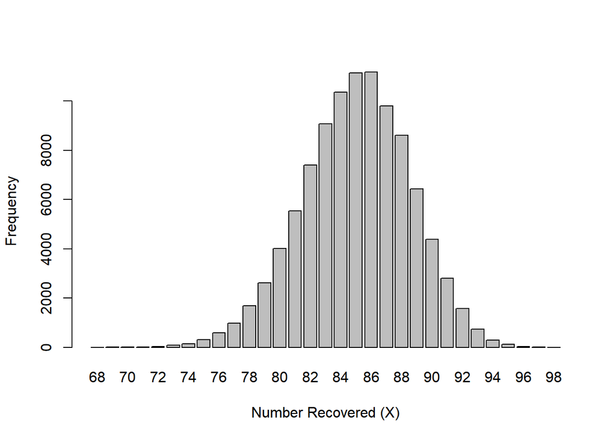

```r
# function to generate exact binomial confidence intervals for a single sample:
get_exact_binomial_confint <- function( n, x, alpha ){

    if( n == x ){ upper_limit <- 1 } else{
      upper_limit <- (      ((x+1)/(n-x)) * qf(df1=2*(x+1), df2=2*(n-x), p=1-alpha/2)   ) /
                     (  1 + ((x+1)/(n-x)) * qf(df1=2*(x+1), df2=2*(n-x), p=1-alpha/2)   )
    }

    if( x == 0 ){ lower_limit <- 0 } else{
      lower_limit <- 1 / (   1 + ((n-x+1)/x) * qf( df1=2*(n-x+1), df2=2*x, p=1-alpha/2 )  )
    }

  return(
          list( lower_confint = lower_limit,
                upper_confint = upper_limit
              )
        )
}

true_theta <- 0.85

# simulate the 100,000 random samples of size 100
sim_x_values <- rbinom(    n = 1e5L,
                        size = 100,
                        prob = true_theta
                      )

barplot( table(sim_x_values),
         xlab = "Number Recovered (X)",
         ylab = "Frequency"
        )
```

```r
# calculate the exact confidence intervals:
calc_confint <-
  tibble( n_recovered = sim_x_values ) %>%
    mutate( point_estimate = sim_x_values / 100 ) %>%
    mutate( get_confint = map( .x = n_recovered,
                               .f = function(x){
                                 get_exact_binomial_confint(     n = 100,
                                                                 x = x,
                                                             alpha = 0.1
                                 )
                                               }
                              )
    ) %>%
    unnest_wider( col = get_confint ) %>%
    mutate( contains_true_theta = 0.85 >= lower_confint &
                                  0.85 <= upper_confint
          )

# calculate the proportion of samples for which the confidence interval contained
# the true proportion theta=0.85
sum(calc_confint$contains_true_theta) / nrow(calc_confint)
```

```
## [1] 0.93359
```

# Confidence in the difference between the proportions ($\theta_A-\theta_B$)

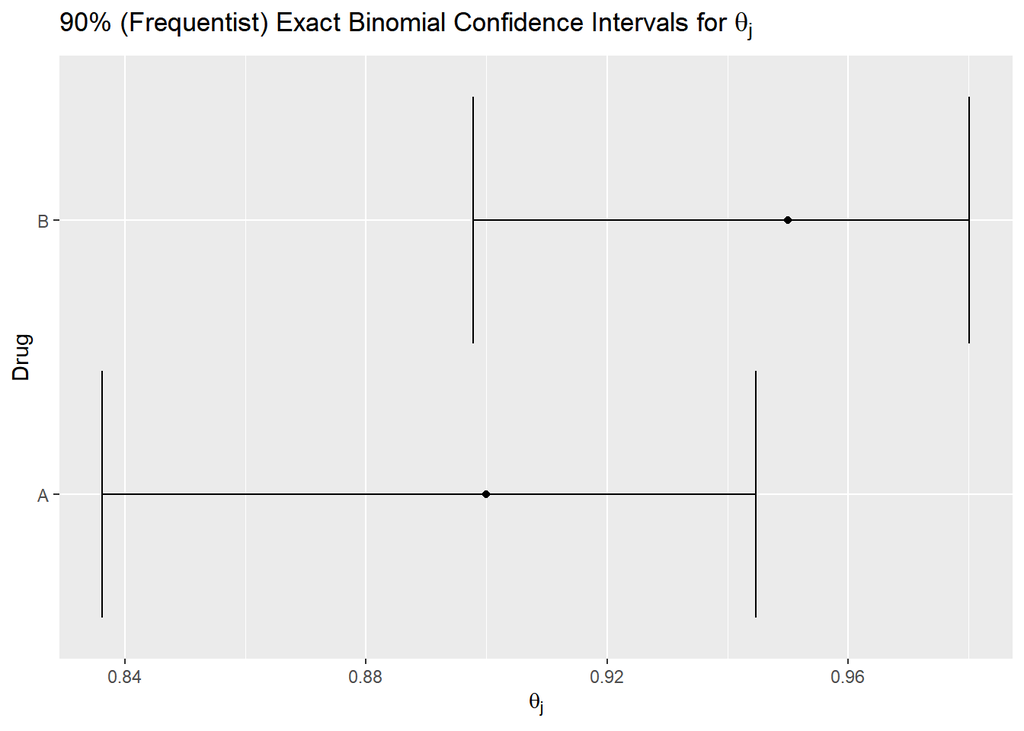

```r
freqentist_exact_intervals_for_theta_A <-
  get_exact_binomial_confint(     n = 100,
                                  x = 90,
                              alpha = 0.1
                            )

freqentist_exact_intervals_for_theta_B <-
  get_exact_binomial_confint(     n = 100,
                                  x = 95,
                              alpha = 0.1
                            )

tibble( theta = c("A","B"),
        point_estimate = c(0.9, 0.95),
        lower = c(freqentist_exact_intervals_for_theta_A$lower_confint,
                  freqentist_exact_intervals_for_theta_B$lower_confint),
        upper = c(freqentist_exact_intervals_for_theta_A$upper_confint,
                  freqentist_exact_intervals_for_theta_B$upper_confint)
      ) %>%
  ggplot( data = .,
          aes( x = theta,
               y = point_estimate
             )
        ) +
  geom_point() +
  geom_errorbar( aes( ymin=lower, ymax=upper) ) +
  coord_flip() +
  labs( y = bquote(theta[j]),
        x = "Drug",
        title = bquote("90% (Frequentist) Exact Binomial Confidence Intervals for "*theta[j])
      )
```